# Industry clusters and ERGMs

# 1 **Prepare for the fight!**

This seminar needs a few packages!  
To collect packages from github  
install.packages(‘devtools’)  
library(devtools)  
Install EconGeo from github  
devtools::install_github(“PABalland/EconGeo”, force = T)  
library(EconGeo)  
ERGM is part of the statnet package  
install.packages(‘statnet’)  
library(statnet)

```r
library(EconGeo)
library(statnet)
library(dplyr)
```

# 2 **Cluster identification**

*EconGeo package* is a collection of functions used frequently in economic geography related research.

‘hun-patents.csv’ contains data on the number of patents in 4-digit technology classes in Hungarian regions along 2001-2010  
‘reg_code’ - NUTS3 codes of Hungarian regions  
‘prio_year’ - patent application year  
‘tech’ - 4-digit technology class  
‘nr_patents’ - number of patents  
The aim is to identify clusters based on patents filed between 2006-2010 in Bács-Kiskun county and in Győr-Moson-Sopron county. After we reveal comparative advantages of these counties, check the overlap of concentrated technologies between the two regions.

```r
# import patent data
pat_df <- data.frame(read.csv('hun-patents.csv', header = TRUE, sep=';'))
print(head(pat_df))
```

```
##   reg_code prio_year tech nr_patents
## 1    HU101      2001 A01K          1
## 2    HU101      2001 A01N          2
## 3    HU101      2001 A23L          1
## 4    HU101      2001 A47J          1
## 5    HU101      2001 A61B          2
## 6    HU101      2001 A61K         14
```

```r
# filter the data by years and sum up patents by technology and region
pat_df2010 <- pat_df %>%
  filter(prio_year >= 2006 & prio_year <= 2010) %>%
  select(-prio_year) %>%
  group_by(reg_code, tech) %>%
  summarize(nr_patents = sum(nr_patents))
```

```r
# create a matrix where rows are regions and columns are technologies
pat_df2010 <- data.frame(pat_df2010)
mat2010 <- get.matrix(pat_df2010)
mat2010[1:6,1:6] # check the first 6 rows and 6 columns
```

```
##       A01B A01C A01D A01G A01K A01M
## HU101    0    1    0    0    0    1
## HU102    0    0    0    0    3    1
## HU211    0    1    0    1    0    0
## HU212    0    0    0    0    0    1
## HU213    0    0    0    0    0    0
## HU221    0    0    0    1    0    0
```

```r
# compute RCA for every technology in every region
rca_mat <- RCA(mat2010)
rca_mat[1:6,1:6] # check the first 6 rows and 6 columns
```

```
##       A01B      A01C A01D     A01G     A01K       A01M
## HU101    0  1.247173    0 0.000000 0.000000  0.8314486
## HU102    0  0.000000    0 0.000000 1.541431  1.7127011
## HU211    0 19.061728    0 7.624691 0.000000  0.0000000
## HU212    0  0.000000    0 0.000000 0.000000 19.0617284
## HU213    0  0.000000    0 0.000000 0.000000  0.0000000
## HU221    0  0.000000    0 7.181395 0.000000  0.0000000
```

Remember that RCA > 1 is a potential cluster (see related lecture)!  
‘HU331’ is Bács-Kiskun county and ‘HU221’ is Győr-Moson-Sopron county  
Check the overlap of concentrated technologies between the two counties! Any big differences?

```r
# filter the matrix and construct a data.frame
clusters <- data.frame(rca_mat['HU331',], rca_mat['HU221',])

# reformat
colnames(clusters) <- c('BK_clusters', 'GYM_clusters')
clusters$tech <- rownames(clusters)

# filter to techs concentrated in both regions
same_potentials <- filter(clusters, BK_clusters >1 & GYM_clusters>1)
print(same_potentials)
```

```
##    BK_clusters GYM_clusters tech
## 1     1.051055     6.905188 B29C
## 2     6.831858     8.976744 B60Q
## 3     1.093097     1.436279 B62D
## 4     1.242156     1.632135 B65D
## 5     2.277286     5.984496 C08J
## 6     2.484312     3.264271 C08L
## 7     5.465487     7.181395 E06B
## 8     4.204221     2.762075 F02D
## 9     2.732743     3.590698 F16F
## 10    2.277286     2.992248 Y02T
```

# 3 **TASK 1**

Search for ‘stable’ clusters in Bács-Kiskun county. Find the technologies that had high RCA over multiple periods (in both 2005 and 2010).  
Suggested steps:  
1. Filter the original pat_df to construct two data.frames for periods 2001-2005 and 2006-2010.  
2. Construct the region-technology matrix and the RCA matrix to both 2005 and 2010 (as above).  
3. Filter both matricies to ‘HU331’ Bács-Kiskunn county. (Note that not necessarily all technologies are present in both periods!)  
4. Merge the data.frames of RCA values into a single dataframe.  
5. Filter the data to technologies with high concentration in both 2005 and 2010.

# 4 **ERGMs**

Exponential Random Graph Models (ERGMs) are quite complicated (see related lecture), but their estimation in R is relative easy! In the following we will do some basic modeling to see whether spinoff companies form more ties in cluster networks, while we control for firm level, dyadic and structural characteristics at the same time.  
*‘network_data.csv’* is a matrix that represents the knowledge network of firms in the printing and paper product cluster of Kecskemét (in 2012).  
*‘firm_properties.csv’* contains information on companies in the network.  
*‘geo_prox_matrix.csv’* is a matrix that represents the geographical proximity of firms in the cluster. (It is measured as the distance of the selected pair of firms subtracted from the maximum physical distance between firms in the cluster.)  
We will use the *statnet package* to estimate ERGMs. Let’s dot it!  
First, import the necessary firm level data!

```r
# import properties data
prop <- data.frame(read.csv("firm_properties.csv", header = TRUE, sep=';'))

# check the data!
print(prop)
```

```
##     ID years_in_industry employee f_owner external_links spinoff
## 1   P1                17        4       0              1       0
## 2   P2                21       80       1              8       0
## 3   P3                10       21       0              0       1
## 4   P4                19        9       0             13       0
## 5   P5                19        2       0              2       0
## 6   P6                21        2       1              0       0
## 7   P7                 2       10       0              1       0
## 8   P8                21       53       1              9       1
## 9   P9                19        2       0              4       1
## 10 P10                 5        5       0              5       1
## 11 P11                16        5       0              7       1
## 12 P12                23       22       0              5       1
## 13 P13                 2        9       0              3       0
## 14 P15                17        5       0              9       0
## 15 P16                23        4       0             18       0
## 16 P17                17       57       0             21       1
## 17 P18                10        6       0              4       0
## 18 P19                 3       19       1              1       1
## 19 P20                12      389       1             14       0
## 20 P21                14        5       0              6       0
## 21 P22                 5        3       0              2       0
## 22 P23                18        5       0              0       1
## 23 P24                14       20       1             50       0
## 24 P25                 6        8       0              4       0
## 25 P26                19        6       0              5       1
## 26 P30                12        4       0              1       1
```

```r
# take log of emp
prop$ln_emp <- log(prop$employee)
```

Second, construct the network!  
Note that this is NOT the usual *igraph* object, we use *statnet* this time!

```r
# create _network object
network_data <-as.matrix(read.csv("network_data.csv", sep=";", header=TRUE, row.names = 1))
knet <- as.network(network_data, directed=TRUE)
knet
```

```
##  Network attributes:
##   vertices = 26
##   directed = TRUE
##   hyper = FALSE
##   loops = FALSE
##   multiple = FALSE
##   bipartite = FALSE
##   total edges= 223
##     missing edges= 0
##     non-missing edges= 223
##
##  Vertex attribute names:
##     vertex.names
##
## No edge attributes
```

*‘knet’* is the knowledge network behind the printing and paper product cluster in Kecskemét. Nodes are companies and edges represent asking technical advice from the other firm.  
As we want to know how firm properties determine the formation of the network, we add properties to network nodes.

```r
# add node attributes
set.vertex.attribute(knet, "ln_emp", prop$ln_emp)
set.vertex.attribute(knet, "experience", prop$years_in_industry)
set.vertex.attribute(knet, "ownership", prop$f_owner)
set.vertex.attribute(knet, "external_links", prop$external_links)
set.vertex.attribute(knet, "spinoff", prop$spinoff)

# check the network object
knet
```

```
##  Network attributes:
##   vertices = 26
##   directed = TRUE
##   hyper = FALSE
##   loops = FALSE
##   multiple = FALSE
##   bipartite = FALSE
##   total edges= 223
##     missing edges= 0
##     non-missing edges= 223
##
##  Vertex attribute names:
##     experience external_links ln_emp ownership spinoff vertex.names
##
## No edge attributes
```

Before we do any estimations, please set the seed for reproducability.

```r
# seed for random network generation
set.seed(10)
```

We begin with a simple model, containing only two term. By the ergm-term *edges* we control for the total number of edges in the network. Additionally, we also control for the experience of companies by *nodecov(‘experience’)*.

```r
# check the variable 'experience'
summary(prop$years_in_industry)
```

```
##    Min. 1st Qu.  Median    Mean 3rd Qu.    Max.
##    2.00   10.00   16.50   14.04   19.00   23.00
```

```r
# estimate a simple model with edges and experience
model01 <- ergm(knet ~ edges + nodecov('experience'))
```

```
## Starting maximum pseudolikelihood estimation (MPLE):
```

```
## Evaluating the predictor and response matrix.
```

```
## Maximizing the pseudolikelihood.
```

```
## Finished MPLE.
```

```
## Stopping at the initial estimate.
```

```
## Evaluating log-likelihood at the estimate.
```

Look at the summary of the fitted model

```r
summary(model01)
```

```
##
## ==========================
## Summary of model fit
## ==========================
##
## Formula:   knet ~ edges + nodecov("experience")
##
## Iterations:  4 out of 20
##
## Monte Carlo MLE Results:
##                     Estimate Std. Error MCMC % z value Pr(>|z|)
## edges              -1.211843   0.276384      0  -4.385   <1e-04 ***
## nodecov.experience  0.019838   0.009215      0   2.153   0.0313 *
## ---
## Signif. codes:  0 '***' 0.001 '**' 0.01 '*' 0.05 '.' 0.1 ' ' 1
##
##      Null Deviance: 901.1  on 650  degrees of freedom
##  Residual Deviance: 831.3  on 648  degrees of freedom
##
## AIC: 835.3    BIC: 844.2    (Smaller is better.)
```

Wow, great! We estimated an ERGM!  
And yes, there is a significant positive experience effect on the probability of a tie. This means that experienced firms are more connected than they would be in random network settings.

How do we interpret the coefficients here? Note that the experience effect operates on both nodes in a dyad. The conditional log-odds of a tie between two actors is:  
−1.21 × change in the number of ties + 0.02 × experience of node A + 0.02 × experience of node B  
−1.21 × change in the number of ties + 0.02 × the sum of the experience of the two nodes  
For a tie between two nodes with minimum experience, the conditional log-odds is:  
−1.21 + 0.02 * (2 + 2) = -1.13  
For a tie between two nodes with maximum experience:  
−1.21 + 0.02 * (23 + 23) = -0.29  
For a tie between a node with maximum experience and a node with minimum experience:  
−1.21 + 0.02 * (23 + 2) = -0.71  
The corresponding probabilities are 0.24, 0.43, and 0.33. (as exp(-1.13)/(1+exp(-1.13)) = 0.24, …)

If you are interested in the maths behind interpretation in various model settings, please visit http://statnet.org/Workshops/ergm_tutorial.html  
So far so good! Now also add controls for employment, external knowledge ties, ownership and spinoff background.  
Note, that we used ‘nodecov’ to include a node level continous variable to our model. BUT - there are many different terms to add further variables to ERGMs - see *help(“ergm-terms”)*.

```r
# estimate model02
model02 <- ergm(knet ~ edges + nodecov('spinoff')
                + nodematch('ownership') # group homophily
                + nodecov('experience')
                + nodecov('external_links')
                + nodecov('ln_emp'))
```

```
## Starting maximum pseudolikelihood estimation (MPLE):
```

```
## Evaluating the predictor and response matrix.
```

```
## Maximizing the pseudolikelihood.
```

```
## Finished MPLE.
```

```
## Stopping at the initial estimate.
```

```
## Evaluating log-likelihood at the estimate.
```

```r
summary(model02)
```

```
##
## ==========================
## Summary of model fit
## ==========================
##
## Formula:   knet ~ edges + nodecov("spinoff") + nodematch("ownership") +
##     nodecov("experience") + nodecov("external_links") + nodecov("ln_emp")
##
## Iterations:  4 out of 20
##
## Monte Carlo MLE Results:
##                         Estimate Std. Error MCMC % z value Pr(>|z|)
## edges                  -2.500460   0.445756      0  -5.609  < 1e-04 ***
## nodecov.spinoff         0.400294   0.131222      0   3.051  0.00228 **
## nodematch.ownership     0.849127   0.202928      0   4.184  < 1e-04 ***
## nodecov.experience      0.015504   0.009895      0   1.567  0.11717
## nodecov.external_links  0.016288   0.006863      0   2.373  0.01763 *
## nodecov.ln_emp          0.057666   0.057650      0   1.000  0.31718
## ---
## Signif. codes:  0 '***' 0.001 '**' 0.01 '*' 0.05 '.' 0.1 ' ' 1
##
##      Null Deviance: 901.1  on 650  degrees of freedom
##  Residual Deviance: 799.1  on 644  degrees of freedom
##
## AIC: 811.1    BIC: 838    (Smaller is better.)
```

While experience is not significant in this setting, spinoff background seems to influence network ties of companies significantly.  
We can use ‘nodematch’ to control for group homophily. It means that we control for whether ties are formed more likely inside groups than they would randomly. In our case ownership group homophily (in terms of foreign-owned and domestic companies) is actually the strongest explanatory factor. It suggests that foreign-owned firms are more likely to share knowledge with other foreign-owned firms, while domestic companies most likely collaborate with other domestic companies.

It is all very cool, but maybe structural features are more important for network tie formation than firm properties.  
In the following model we introduce network effects such as *GWESP* and *GWDSP* to control for triads and indirect relationships.  
*GWESP - Geometrically weighted edgewise shared partner distribution* - it counts the number of common third partners for each *i,j* connected nodes. It reflect on the tendency to form triads in the network.  
*GWDSP - Geometrically weighted dyad-wise shared partners* - it counts the number of common third partners for each *i,j* dyads, that are not connected directly. It measures the extent to which nodes are not directly linked to each other, being at least indirectly linked.  
Both variables are great for the aims of ERGMs, but in most cases their parameters should be manually set. This means a lot of trial and error, but at least the models usually converge well!  
See an example where we do not set GWESP and GWDSP manually.

```r
# estimate model03A
model03A <- ergm(knet ~ edges + nodecov('spinoff')
                + nodematch('ownership') # group homophily
                + nodecov('experience')
                + nodecov('external_links')
                + nodecov('ln_emp')
                + gwesp(fixed=FALSE) + gwdsp(fixed=FALSE))
```

```
## Starting maximum pseudolikelihood estimation (MPLE):
```

```
## Evaluating the predictor and response matrix.
```

```
## Maximizing the pseudolikelihood.
```

```
## Finished MPLE.
```

```
## Starting Monte Carlo maximum likelihood estimation (MCMLE):
```

```
## Iteration 1 of at most 20:
```

```
## Optimizing with step length 0.303498629372087.
```

```
## The log-likelihood improved by 4.217.
```

```
## Iteration 2 of at most 20:
```

```
## Optimizing with step length 0.404250935414655.
```

```
## The log-likelihood improved by 2.706.
```

```
## Iteration 3 of at most 20:
```

```
## Optimizing with step length 0.579798084038295.
```

```
## The log-likelihood improved by 1.519.
```

```
## Iteration 4 of at most 20:
```

```
## Optimizing with step length 1.
```

```
## The log-likelihood improved by 0.2353.
```

```
## Step length converged once. Increasing MCMC sample size.
```

```
## Iteration 5 of at most 20:
```

```
## Optimizing with step length 1.
```

```
## Error in solve.default(H, tol = 1e-20) :
##   system is computationally singular: reciprocal condition number = 1.60296e-29
```

```
## The log-likelihood improved by 0.03532.
```

```
## Step length converged twice. Stopping.
```

```
## Finished MCMLE.
```

```
## Evaluating log-likelihood at the estimate. Using 20 bridges: 1 2 3 4 5 6 7 8 9 10 11 12 13 14 15 16 17 18 19 20 .
## This model was fit using MCMC.  To examine model diagnostics and
## check for degeneracy, use the mcmc.diagnostics() function.
```

```r
summary(model03A)
```

```
##
## ==========================
## Summary of model fit
## ==========================
##
## Formula:   knet ~ edges + nodecov("spinoff") + nodematch("ownership") +
##     nodecov("experience") + nodecov("external_links") + nodecov("ln_emp") +
##     gwesp(fixed = FALSE) + gwdsp(fixed = FALSE)
##
## Iterations:  5 out of 20
##
## Monte Carlo MLE Results:
##                         Estimate Std. Error MCMC % z value Pr(>|z|)
## edges                  -2.909265         NA     NA      NA       NA
## nodecov.spinoff         0.101364         NA     NA      NA       NA
## nodematch.ownership     0.374100         NA     NA      NA       NA
## nodecov.experience      0.005004         NA     NA      NA       NA
## nodecov.external_links  0.005302         NA     NA      NA       NA
## nodecov.ln_emp          0.045313         NA     NA      NA       NA
## gwesp                   0.541257         NA     NA      NA       NA
## gwesp.decay             1.698660         NA     NA      NA       NA
## gwdsp                  -0.090065         NA     NA      NA       NA
## gwdsp.decay            28.487232         NA     NA      NA       NA
##
##      Null Deviance: 901.1  on 650  degrees of freedom
##  Residual Deviance: 704.3  on 640  degrees of freedom
##
## AIC: 724.3    BIC: 769.1    (Smaller is better.)
```

The model does not converge.. So use fixed values for GWESP and GWDSP.  
Recommendation:

```r
# estimate model03A
model03B <- ergm(knet ~ edges + nodecov('spinoff')
                + nodematch('ownership') # group homophily
                + nodecov('experience')
                + nodecov('external_links')
                + nodecov('ln_emp')
                + gwesp(0.2, fixed=TRUE) + gwdsp(1, fixed=TRUE))
```

```
## Starting maximum pseudolikelihood estimation (MPLE):
```

```
## Evaluating the predictor and response matrix.
```

```
## Maximizing the pseudolikelihood.
```

```
## Finished MPLE.
```

```
## Starting Monte Carlo maximum likelihood estimation (MCMLE):
```

```
## Iteration 1 of at most 20:
```

```
## Optimizing with step length 0.839281866174271.
```

```
## The log-likelihood improved by 3.283.
```

```
## Iteration 2 of at most 20:
```

```
## Optimizing with step length 1.
```

```
## The log-likelihood improved by 0.2798.
```

```
## Step length converged once. Increasing MCMC sample size.
```

```
## Iteration 3 of at most 20:
```

```
## Optimizing with step length 1.
```

```
## The log-likelihood improved by 0.005372.
```

```
## Step length converged twice. Stopping.
```

```
## Finished MCMLE.
```

```
## Evaluating log-likelihood at the estimate. Using 20 bridges: 1 2 3 4 5 6 7 8 9 10 11 12 13 14 15 16 17 18 19 20 .
## This model was fit using MCMC.  To examine model diagnostics and
## check for degeneracy, use the mcmc.diagnostics() function.
```

```r
summary(model03B)
```

```
##
## ==========================
## Summary of model fit
## ==========================
##
## Formula:   knet ~ edges + nodecov("spinoff") + nodematch("ownership") +
##     nodecov("experience") + nodecov("external_links") + nodecov("ln_emp") +
##     gwesp(0.2, fixed = TRUE) + gwdsp(1, fixed = TRUE)
##
## Iterations:  3 out of 20
##
## Monte Carlo MLE Results:
##                         Estimate Std. Error MCMC % z value Pr(>|z|)
## edges                  -4.119636   0.743133      0  -5.544  < 1e-04 ***
## nodecov.spinoff         0.308592   0.118604      0   2.602  0.00927 **
## nodematch.ownership     0.679449   0.171127      0   3.970  < 1e-04 ***
## nodecov.experience      0.012513   0.008258      0   1.515  0.12972
## nodecov.external_links  0.012201   0.006417      0   1.901  0.05726 .
## nodecov.ln_emp          0.051233   0.048802      0   1.050  0.29380
## gwesp.fixed.0.2         2.206372   0.536866      0   4.110  < 1e-04 ***
## gwdsp.fixed.1          -0.206436   0.031260      0  -6.604  < 1e-04 ***
## ---
## Signif. codes:  0 '***' 0.001 '**' 0.01 '*' 0.05 '.' 0.1 ' ' 1
##
##      Null Deviance: 901.1  on 650  degrees of freedom
##  Residual Deviance: 757.0  on 642  degrees of freedom
##
## AIC: 773    BIC: 808.8    (Smaller is better.)
```

The above model shows that spinoff background and ownership group homophily are still significantly influence knowledge network formation.  
Additionally, closed triads (GWESP) are more likely than we would expect by chance, while indirect connections (GWDSP) are significantly less likely than they would be randomly.  
We can use AIC and BIC to compare models. Controlling for triads and indirect connections improved the model a lot in comparison to model02.  
GREAT!  
BUT - how do we know that our estimation is precise and the simulated random networks have the same features as our observed network?  
Check Goodness-of-fit (GOF)!

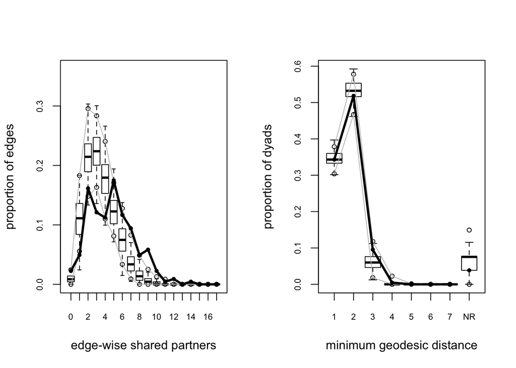

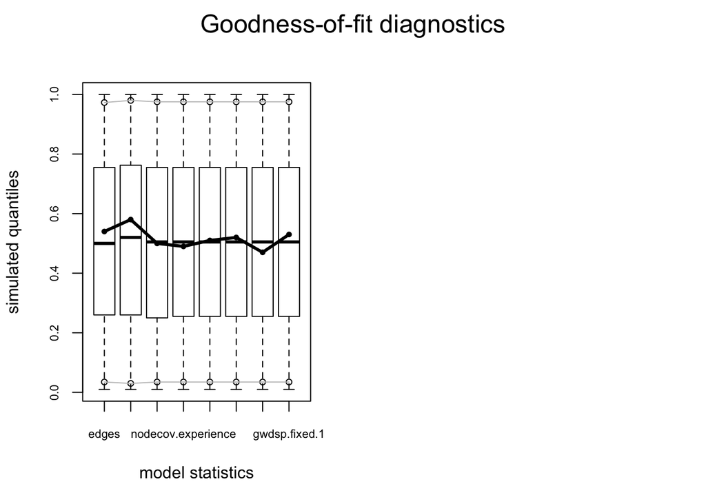

```r
# setup a 2 panel plot
par(mfrow=c(1,2))

# comparison in terms of edgewise shared partners and distance in networks
model_gof <- gof(model03B ~ espartners + distance)
plot(model_gof)
```

As the above figures show the observed network is quite different from the simulated graphs. Our models do not perform well enough at this stage.  
Another important thing to check in order to fix our estimations and improve the goodness-of-fit is *MCMC diagnostics*. When dyad dependent terms are in the model, it is important to assess model convergence before evaluating statistical significance, interpreting coefficients, or assessing goodness of fit. MCMC diagnostics plots how the Markov Chain Montre Carlo process behind random network generation went down.

```r
# run mcmc diagnostics
mcmc.diagnostics(model03B)
```

```
## Sample statistics summary:
##
## Iterations = 16384:4209664
## Thinning interval = 1024
## Number of chains = 1
## Sample size per chain = 4096
##
## 1. Empirical mean and standard deviation for each variable,
##    plus standard error of the mean:
##
##                            Mean     SD Naive SE Time-series SE
## edges                   -0.4148  13.03   0.2036         0.3086
## nodecov.spinoff         -0.2961  13.66   0.2135         0.2833
## nodematch.ownership     -0.4775  10.58   0.1654         0.2525
## nodecov.experience      -7.4863 383.25   5.9883         9.0074
## nodecov.external_links -16.1130 260.19   4.0655         5.7816
## nodecov.ln_emp          -3.0059  62.51   0.9767         1.4845
## gwesp.fixed.0.2         -0.5784  17.53   0.2739         0.4057
## gwdsp.fixed.1           -2.4018  84.97   1.3276         2.2858
##
## 2. Quantiles for each variable:
##
##                           2.5%     25%      50%    75%  97.5%
## edges                   -27.00   -9.00  -1.0000   9.00  24.00
## nodecov.spinoff         -27.00   -9.00   0.0000   9.00  26.00
## nodematch.ownership     -22.00   -8.00   0.0000   7.00  19.00
## nodecov.experience     -754.25 -264.00 -14.5000 255.00 723.88
## nodecov.external_links -499.62 -197.00 -18.0000 158.00 505.25
## nodecov.ln_emp         -126.15  -44.73  -4.2745  39.58 119.42
## gwesp.fixed.0.2         -35.77  -12.23  -0.6024  11.36  32.97
## gwdsp.fixed.1          -165.16  -60.71  -4.1906  56.15 165.74
##
##
## Sample statistics cross-correlations:
##                            edges nodecov.spinoff nodematch.ownership
## edges                  1.0000000       0.7579087           0.7796152
## nodecov.spinoff        0.7579087       1.0000000           0.5886011
## nodematch.ownership    0.7796152       0.5886011           1.0000000
## nodecov.experience     0.9441615       0.7315248           0.7092946
## nodecov.external_links 0.7264008       0.4721322           0.4472459
```

[output cut: 52 more lines]

```
##                  edges        nodecov.spinoff    nodematch.ownership
##                -1.2837                -0.5240                -0.4696
##     nodecov.experience nodecov.external_links         nodecov.ln_emp
##                -0.7436                -1.5587                -1.9307
##        gwesp.fixed.0.2          gwdsp.fixed.1
##                -1.2060                -0.5594
##
## Individual P-values (lower = worse):
##                  edges        nodecov.spinoff    nodematch.ownership
##             0.19924126             0.60026107             0.63867371
##     nodecov.experience nodecov.external_links         nodecov.ln_emp
##             0.45714776             0.11906096             0.05352323
##        gwesp.fixed.0.2          gwdsp.fixed.1
##             0.22782952             0.57586895
## Joint P-value (lower = worse):  0.1066892 .
```

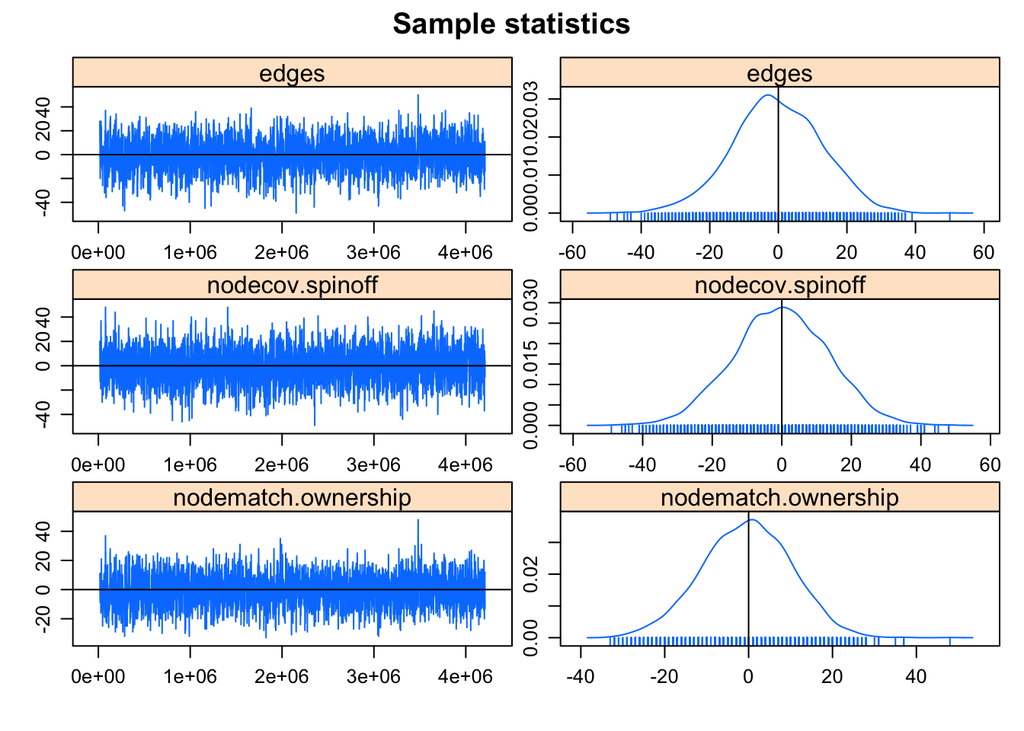

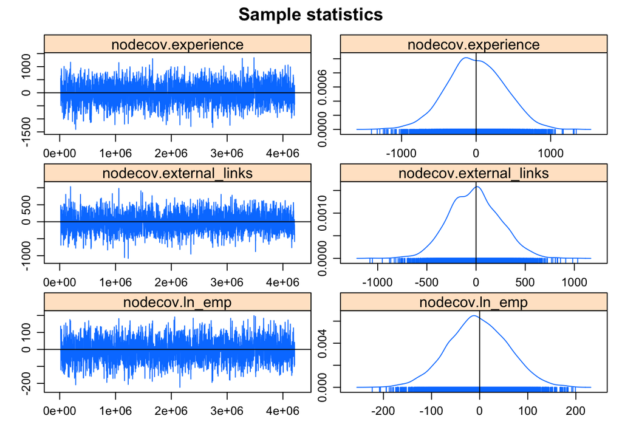

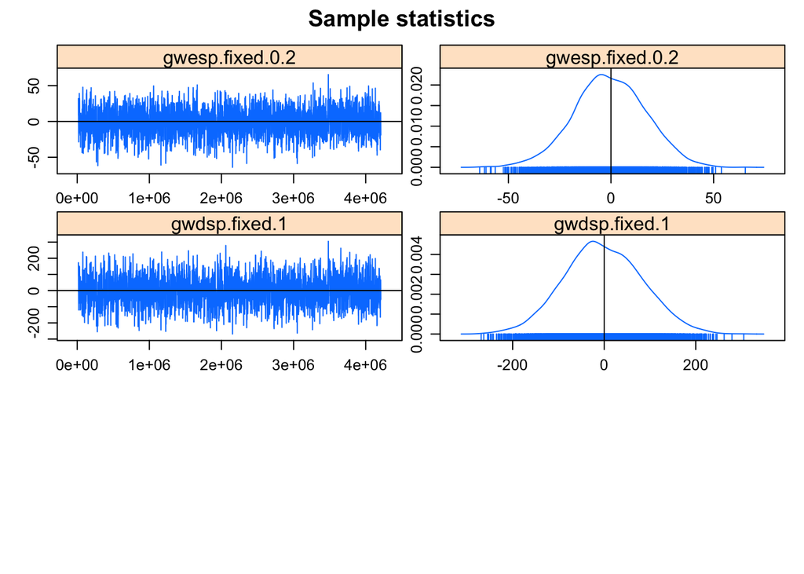

[output not shown]

What the above figures show is statistics from the final iteration of the MCMC chain, on the left as a “traceplot” (the deviation of the statistic value in each sampled network from the observed value), and on the right as the distribution of the sample statistic deviations. This is what you want to see in the MCMC diagnostics: the MCMC sample statistics are varying randomly around the observed values at each step (so the chain is “mixing” well), the sampled values show little serial correlation and the difference between the observed and simulated values of the sample statistics have a roughly bell-shaped distribution, centered at 0.  
By trial and error you can improve the MCMC process, which will also impact your goodness-of-fit! This is the difficult and time consuming part of ERGMs.  
(It is usually the best to begin with the fixed parameters of GWESP and GWDSP.)  
One more thing! We discussed on most lectures that geographical proximity matters. How can we control for the influence of geographical proximity on tie formation?

```r
# import the geographic proximity matrix
geoprox <- as.matrix(read.csv("geo_prox_matrix.csv", sep=";", header=TRUE, row.names = 1))

# create a network!
geo_network <- as.network(geoprox, directed = TRUE)

# add edge values to geo_network
set.edge.value(geo_network, "geoprox", geoprox)
```

As ‘geo_network’ and ‘knet’ consist of the same nodeset, we can use the edge weight of geo_network to explain edges in knet.

```r
# estimate model03A
model04 <- ergm(knet ~ edges + nodecov('spinoff')
                + nodematch('ownership') # group homophily
                + nodecov('experience')
                + nodecov('external_links')
                + nodecov('ln_emp')
                + gwesp(0.2, fixed=TRUE) + gwdsp(1, fixed=TRUE)
                + edgecov(geo_network, "geoprox"))
```

```
## Starting maximum pseudolikelihood estimation (MPLE):
```

```
## Evaluating the predictor and response matrix.
```

```
## Maximizing the pseudolikelihood.
```

```
## Finished MPLE.
```

```
## Starting Monte Carlo maximum likelihood estimation (MCMLE):
```

```
## Iteration 1 of at most 20:
```

```
## Optimizing with step length 0.917528475487807.
```

```
## The log-likelihood improved by 3.793.
```

```
## Iteration 2 of at most 20:
```

```
## Optimizing with step length 1.
```

```
## The log-likelihood improved by 0.1409.
```

```
## Step length converged once. Increasing MCMC sample size.
```

```
## Iteration 3 of at most 20:
```

```
## Optimizing with step length 1.
```

```
## The log-likelihood improved by 0.01678.
```

```
## Step length converged twice. Stopping.
```

```
## Finished MCMLE.
```

```
## Evaluating log-likelihood at the estimate. Using 20 bridges: 1 2 3 4 5 6 7 8 9 10 11 12 13 14 15 16 17 18 19 20 .
## This model was fit using MCMC.  To examine model diagnostics and
## check for degeneracy, use the mcmc.diagnostics() function.
```

```r
summary(model04)
```

```
##
## ==========================
## Summary of model fit
## ==========================
##
## Formula:   knet ~ edges + nodecov("spinoff") + nodematch("ownership") +
##     nodecov("experience") + nodecov("external_links") + nodecov("ln_emp") +
##     gwesp(0.2, fixed = TRUE) + gwdsp(1, fixed = TRUE) + edgecov(geo_network,
##     "geoprox")
##
## Iterations:  3 out of 20
##
## Monte Carlo MLE Results:
##                         Estimate Std. Error MCMC % z value Pr(>|z|)
## edges                  -4.867055   0.726898      0  -6.696  < 1e-04 ***
## nodecov.spinoff         0.438485   0.127422      0   3.441 0.000579 ***
## nodematch.ownership     0.727749   0.174555      0   4.169  < 1e-04 ***
## nodecov.experience      0.006132   0.008418      0   0.728 0.466358
## nodecov.external_links  0.015714   0.006561      0   2.395 0.016624 *
## nodecov.ln_emp          0.033270   0.050011      0   0.665 0.505880
## gwesp.fixed.0.2         2.002531   0.500070      0   4.004  < 1e-04 ***
## gwdsp.fixed.1          -0.204005   0.030889      0  -6.605  < 1e-04 ***
## edgecov.geoprox         0.134627   0.039406      0   3.416 0.000634 ***
## ---
## Signif. codes:  0 '***' 0.001 '**' 0.01 '*' 0.05 '.' 0.1 ' ' 1
##
##      Null Deviance: 901.1  on 650  degrees of freedom
##  Residual Deviance: 744.7  on 641  degrees of freedom
##
## AIC: 762.7    BIC: 803    (Smaller is better.)
```

The above models show positive and significant effect for geographical proximity on network tie formation.

# 5 **Useful references**

Goodreau, S., J. Kitts and M. Morris (2009): Birds of a Feather, or Friend of a Friend? Using Statistical Network Analysis to Investigate Adolescent Social Networks. *Demography*, 46 (1), 103-125.  
Hunter, D. R., Goodreau, S. M. and Handcock, M. S. (2008): Goodness of fit for social network models. *Journal of the American Statistical Association*, 103 (481), 248–258.  
Robins, R., Snijders, T., Wang, P., Handcock, M. and Pattison, P. (2007a): Recent developments in the exponential random graph (p) models for social networks. *Social Networks*, 29 (2), 192–215.  
Robins, G., Pattison, P., Kalish, Y. and Lusher, D. (2007b): An introduction to exponential random graph (p) models for social networks. *Social Networks*, 29 (2), 173–191.  
Juhász, S. (2019): Spinoffs and tie formation in cluster knowledge networks. *Small Business Economics*, 1-20.  
Snijders, T., Pattison, P. E., Robins, G. L. and Handcock, M. S. (2006): New specifications for exponential random graph models. *Sociological Methodology*, 36 (1), 99-153.  
https://github.com/sandorjuhasz/ergm-cluster http://statnet.org/Workshops/ergm_tutorial.html#1_statistical_network_modeling_with_ergms